# Лабораторная работа №8

Настройка SMTP-сервера

Устинова В. В.

Российский университет дружбы народов, Москва, Россия

24 октября 2026

# Информация

## Докладчик

- Устинова Виктория Вадимовна
- студент НПИбд-01-24
- Российский университет дружбы народов

# Вводная часть

## Цель работы

Приобретение практических навыков по установке и конфигурированию SMTP-сервера.

## Задание

1. Установите на виртуальной машине server SMTP-сервер postfix (см. раздел 8.4.1).
2. Сделайте первоначальную настройку postfix при помощи утилиты postconf, задав отправку писем не на локальный хост, а на сервер в домене (см. раздел 8.4.2).
3. Проверьте отправку почты с сервера и клиента (см. раздел 8.4.3).
4. Сконфигурируйте Postfix для работы в домене. Проверьте отправку почты с сервера и клиента (см. раздел 8.4.4).
5. Напишите скрипт для Vagrant, фиксирующий действия по установке и настройке Postfix во внутреннем окружении виртуальной машины server. Соответствующим образом внесите изменения в Vagrantfile (см. раздел 8.4.5).

# Выполнение

## Установка пакетов

На виртуальной машине server под суперпользователем установлены пакеты postfix и s-nail.

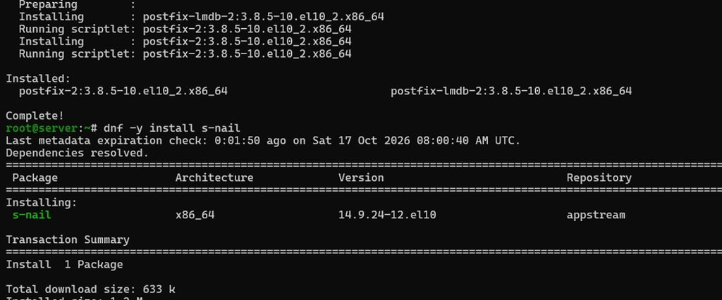

Установка пакетов postfix и s-nail на виртуальной машине server

## Межсетевой экран и запуск Postfix

Служба SMTP разрешена в межсетевом экране (в текущей и постоянной конфигурации), восстановлен контекст безопасности SELinux, Postfix включён в автозапуск и запущен.

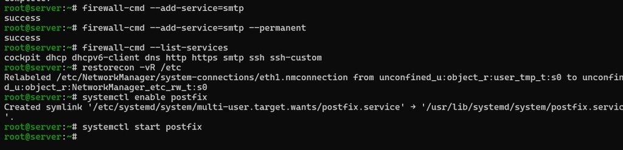

Разрешение службы smtp в межсетевом экране, восстановление контекста SELinux, запуск Postfix

## Параметры myorigin и mydomain

Просмотрены значения параметров, myorigin заменён на $mydomain. Первая попытка завершилась ошибкой из-за типографских кавычек, со вторым вариантом команды замена выполнена.

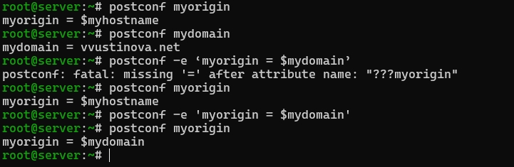

Просмотр параметров myorigin и mydomain и замена myorigin на $mydomain

## Проверка конфигурации

Корректность main.cf проверена командой `postfix check`, конфигурация перечитана командой `systemctl reload postfix`, выведены параметры, отличные от значений по умолчанию.

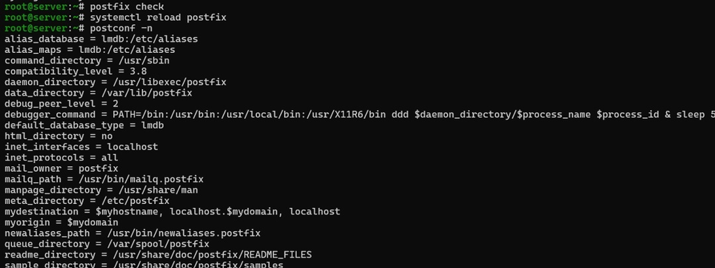

Проверка конфигурации, перезагрузка Postfix и вывод изменённых параметров

## Домен и протоколы

В конце вывода виден `myorigin = $mydomain`. Домен задан жёстко, в параметре inet_protocols значение all заменено на ipv4, конфигурация перезагружена.

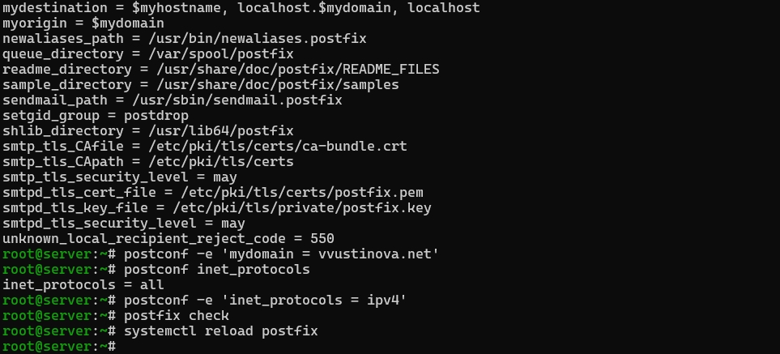

Жёсткое задание домена и отключение IPv6 в параметре inet_protocols

## Отправка письма на сервере

Под пользователем отправлено письмо test1, запущен мониторинг журнала. Статус `status=sent (delivered to mailbox)` показывает, что письмо доставлено. Предупреждение сообщает, что inet_protocols применится после остановки и запуска Postfix.

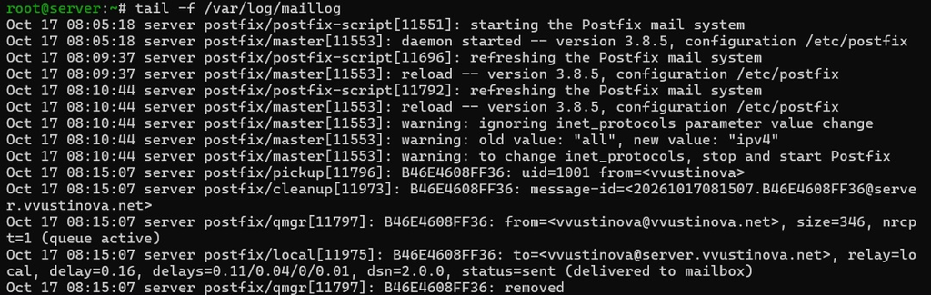

Журнал maillog: письмо test1 доставлено в почтовый ящик

## Почтовый ящик пользователя

В каталоге `/var/spool/mail` появился файл пользователя vvustinova с письмом test1. В заголовках отправитель `vvustinova@vvustinova.net`, то есть myorigin применился.

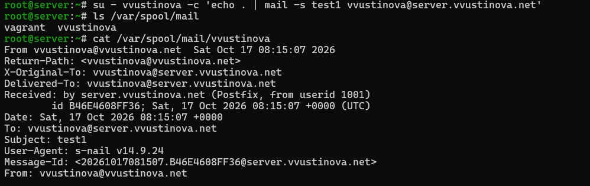

Каталог /var/spool/mail и содержимое почтового ящика пользователя

## Отправка письма с клиента

На клиенте установлены postfix и s-nail, отключён IPv6, Postfix запущен. Письмо test2 осталось в очереди с ошибкой `Connection refused` при подключении к серверу на порт 25.

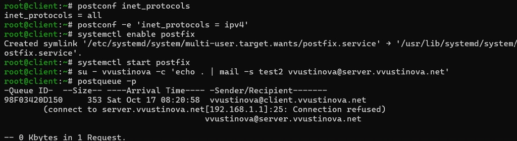

Настройка Postfix на клиенте и письмо test2, застрявшее в очереди

## Настройка интерфейсов и сетей

На сервере `inet_interfaces = localhost`, поэтому внешние соединения не принимались. Значение заменено на all, в mynetworks добавлена внутренняя сеть, Postfix перезапущен.

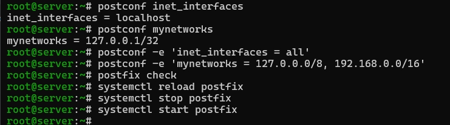

Разрешение Postfix принимать соединения со всех интерфейсов и из внутренней сети

## Повторная отправка с клиента

В журнале сервера видно подключение клиента, приём сообщения и доставка со статусом `status=sent (delivered to mailbox)`.

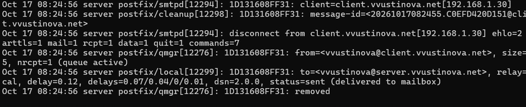

Журнал сервера: письмо с клиента принято и доставлено в почтовый ящик

## Письмо на доменный адрес

С клиента отправлено письмо test3 на адрес `vvustinova@vvustinova.net`. Очередь клиента по-прежнему содержит прежнее недоставленное сообщение.

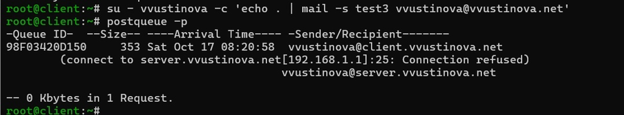

Отправка письма test3 с клиента на доменный адрес и просмотр очереди

## Ошибка доставки на домен

Письмо возвращено со статусом `bounced (mail for vvustinova.net loops back to myself)`: сервер не считает домен конечной точкой доставки. Уведомление клиенту не ушло из-за ошибки `No route to host`.

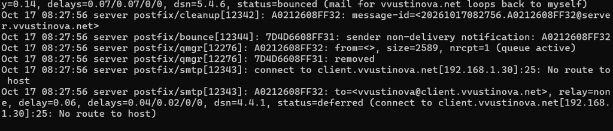

Журнал сервера: письмо на доменный адрес вернулось с ошибкой loops back to myself

## Прямая DNS-зона

В файл прямой зоны добавлены MX-запись `MX 10 mail.vvustinova.net.` и запись `mail A 192.168.1.1`.

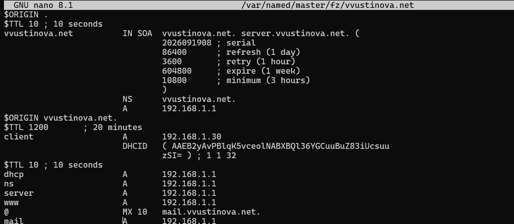

Файл прямой DNS-зоны с MX-записью и записью mail

## Обратная DNS-зона

В файл обратной зоны добавлена запись `1 PTR mail.vvustinova.net.`.

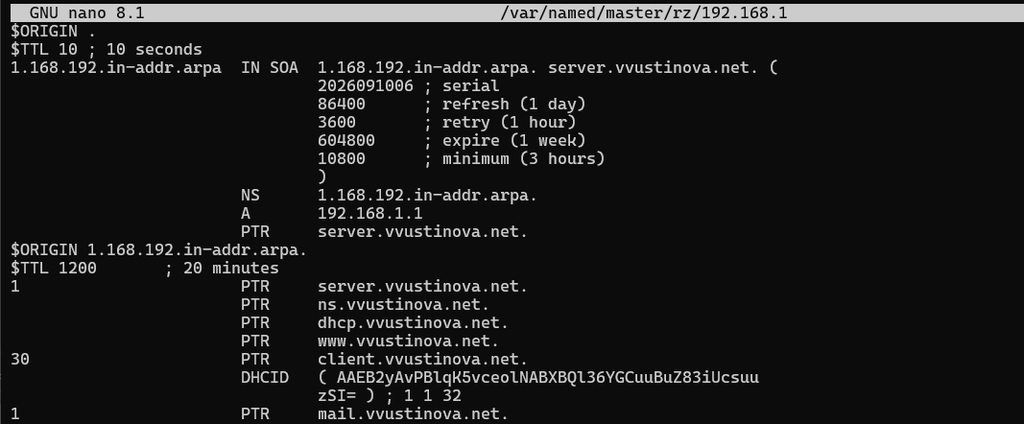

Файл обратной DNS-зоны с PTR-записью для mail

## Доставка

Домен добавлен в mydestination, перезагружен Postfix, восстановлены контексты SELinux, перезапущен DNS и отправлены сообщения из очереди. Письмо на доменный адрес доставлено.

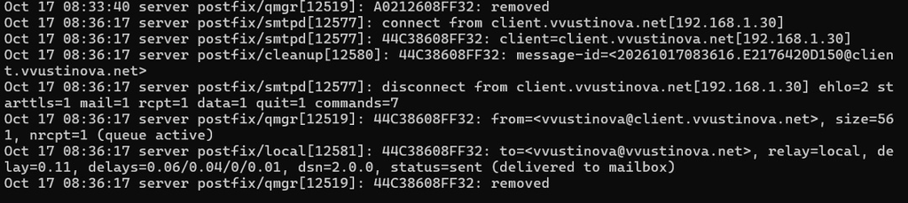

Журнал сервера: письмо на доменный адрес доставлено

## Скрипт mail.sh для сервера

Скрипт устанавливает postfix и s-nail, разрешает службу smtp в межсетевом экране, восстанавливает контексты SELinux, запускает Postfix и задаёт его параметры.

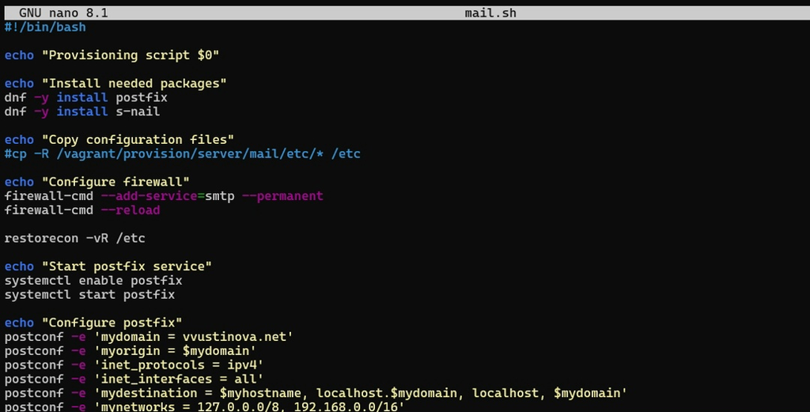

Скрипт mail.sh для виртуальной машины server

## Скрипт mail.sh для клиента

Скрипт устанавливает postfix и s-nail, отключает IPv6, включает и запускает Postfix.

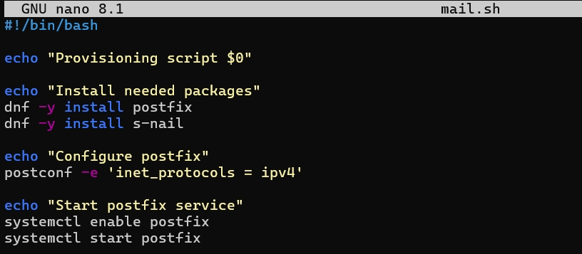

Скрипт mail.sh для виртуальной машины client

## Vagrantfile: сервер

В конфигурацию сервера добавлена запись provision «server mail».

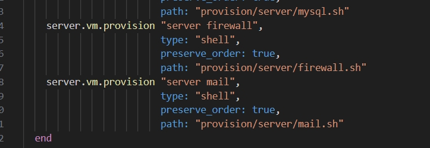

Запись server mail в Vagrantfile

## Vagrantfile: клиент

В конфигурацию клиента добавлена запись provision «client mail».

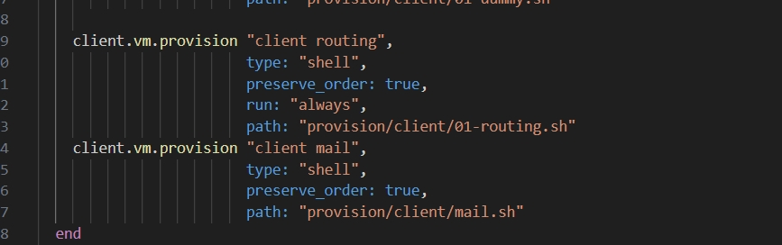

Запись client mail в Vagrantfile

# Заключение

## Выводы

В ходе работы получены практические навыки по установке и конфигурированию SMTP-сервера Postfix. Выполнена первоначальная настройка параметров с помощью postconf, проверена отправка почты с сервера и клиента. Для приёма почты от клиента потребовалось разрешить Postfix слушать все интерфейсы и добавить внутреннюю сеть в mynetworks, а для работы с доменным адресом — добавить в DNS MX-запись и указать домен в mydestination. Действия по настройке зафиксированы в скриптах `mail.sh` для сервера и клиента, которые подключены в Vagrantfile.